# 2 TensorFlow Basics

```python
import numpy as np
import pandas as pd
import seaborn as sns
import matplotlib.pyplot as plt
import sys, json

from PIL import Image
from absl.flags import FLAGS
from yolov3_tf2.models import YoloV3
from yolov3_tf2.dataset import transform_images
from yolov3_tf2.utils import draw_outputs
from sklearn.model_selection import StratifiedKFold, train_test_split
from sklearn.preprocessing import StandardScaler
from sklearn.metrics import precision_recall_curve, f1_score, roc_curve, auc, confusion_matrix
from bayes_opt import BayesianOptimization
from gensim.models import KeyedVectors

import tensorflow as tf
import tensorflow_hub as hub
import tensorflow_datasets as tfds
from tensorflow.keras import *
from tensorflow.keras.layers import *
from tensorflow.keras.applications.resnet_v2 import *
from tensorflow.keras.preprocessing.text import Tokenizer
from tensorflow.keras.preprocessing.sequence import pad_sequences
from tensorflow.keras.preprocessing.image import ImageDataGenerator
```

## 1. 表格数据Tabular Data

### 1.1 数据预处理

1. 使用 [df.info] 查找缺失值并用 [df = df.fillna(df.median())] 填充
2. 使用 [df.info] 时如果有数值列显示为object，先用 [df = pd.to_numeric(df, 'coerce')] 将该列只保留数字再用 [df.fillna] 填充
3. 对于连续数值数据，使用 [x = StandardScaler().fit_transform(x)] 作标准化
4. 对于分类文本数据，使用 [y = pd.get_dummies(df['sample'])] 作独热编码，如果仅为二分类也可用 [y = df['sample'].map()] 快速标记

### 1.2 模型构建和优化

单层感知器SLP(Single Layer Perceptron)：只有输入层和输出层，输入特征向量feature vector乘以权重向量weight vector累积总和再加偏置值bias，将其结果传递到激活函数activation function，得到单个输出结果，只能用于二分类而不能解决线性不可分或非线性问题

常见激活函数Activation function：

1. 阶跃函数(Step function)：值域 {0, 1}，基于阈值返回0或1可创建二分类器，梯度为0故不适用反向传播算法，一般只用于单层感知器
2. 线性函数(Linear function)：值域 (-∞, +∞)，导数梯度均为常数故无法适用梯度下降，可用于回归或二分类问题的输出层
3. S函数(Sigmoid function)：值域 (0, 1)，输入值在两端会梯度消失gradient vanish故很少用于隐藏层，输出值恒大于0故收敛速度慢，可用于二分类的输出层
4. 双曲正切函数Tanh(Hyperbolic function)：值域 (-1, 1)，解决了Sigmoid的输出不是0均值的问题，输入值在两端仍会梯度消失，可用于对称性结果的输出层
5. 线性整流函数ReLU(Rectified Linear Unit)：值域 [0, +∞)，非线性梯度不饱和故收敛速度快，梯度大时容易失活，很少用于输出层，广泛用于隐藏层
6. 归一化指数函数(Softmax function)：值域 (0, 1)，将神经元多个输出归一化且总和为1，可以看作各所属分类的概率，常用于多分类问题的输出层

深度神经网络DNN(Deep Neural Network)：即多层感知器MLP(Multi Layer Perceptron)，在单层神经网络的基础上加入隐藏层，每个节点与下一层每个节点都相连的隐藏层叫全连接层fully connected layer也叫密集层dense layer，同属于人工神经网络ANN(Artificial Neural Network)

反向传播算法BP(BackPropagation)：多层神经网络训练的主要算法，其会计算损失函数的梯度并反馈给优化器，用于更新权重以最小化损失函数

常见优化器Optimizer：

1. 批量梯度下降法BGD(Batch Gradient Descent)：梯度下降的原始形式，每次都对整个样本进行计算，收敛速度慢，容易陷入局部极小值
2. 随机梯度下降法SGD(Stochastic Gradient Descent)：每次随机选择一个样本点进行计算，收敛速度快，但会引入一些噪声
3. 小批量梯度下降法MBGD(Mini-Batch Gradient Descent)：每次随机选择小批量样本进行计算，是BGD和SGD的中和
4. 动量法Momentum：SGD的改进，计算当前更新向量时引入上一次更新向量，可以加速收敛，避免陷入局部极小值，动量系数beta通常取值0.9
5. 加速梯度下降法NAG(Nesterov Accelerated Gradient)：Momentum的变种，提供了一种前瞻性的参数更新预估，可以更快地收敛
6. 自适应学习率算法AdaGrad：使不同参数自适应学习率，适用于处理稀疏数据，但总体学习率单调递减并最终趋近于零
7. 均方根传递算法RMSProp：AdaGrad的改进，将参数反比于累计梯度平方和替换为指数加权平均，解决了学习率衰减的问题
8. 自适应增量算法AdaDelta：AdaGrad的改进，在RMSProp的基础上维护了一个额外状态变量以替换学习率参数，解决了学习率衰减的问题
9. 适应性矩估计算法Adam：是RMSProp和Momentum的结合，同时加入了偏差修正，实践表明其效果好于其他自适应优化算法

**1.2.1 正则化Regularization**

L1/L2正则化 L1/L2 regularization：惩罚模型复杂度防止过拟合，L1正则化根据权重的绝对值和来惩罚权重，会使低相关特征的权重降为零，因此也可以对稀疏数据作特征选择，L2正则化根据权重的平方和来惩罚权重，会使离群值的权重接近于零但不等于零，一般比L1正则化更常用，两者可以结合使用

丢弃正则化Dropout regularization：模型训练时在神经网络层中随机丢弃一些单元，使得整个网络不会偏向于某一个特征，降低权重值减少模型复杂度

早停法Early stopping：一种正则化方法，在验证集损失开始增大即范化效果generalization performance变差时结束模型训练，防止过拟合

Tip：模型训练 [model.fit] 自带的 [validation_split] 是不打乱的，若样本按顺序排列可使用 [df = df.sample(frac=1)] 将样本打乱

```python
def plot_history():
    plt.figure(figsize=(14,4))
    plt.subplot(121)
    plt.plot(history.history['loss'], label='loss')
    plt.plot(history.history['val_loss'], label='val_loss')
    plt.legend()
    plt.subplot(122)
    plt.plot(history.history['acc'], label='acc')
    plt.plot(history.history['val_acc'], label='val_acc')
    plt.legend()
```

```python
df = pd.read_csv('iris.csv')
df.head()
```

|  | sepal_l | sepal_w | petal_l | petal_w | species |
| --- | --- | --- | --- | --- | --- |
| 0 | 5.1 | 3.5 | 1.4 | 0.2 | Iris-setosa |
| 1 | 4.9 | 3.0 | 1.4 | 0.2 | Iris-setosa |
| 2 | 4.7 | 3.2 | 1.3 | 0.2 | Iris-setosa |
| 3 | 4.6 | 3.1 | 1.5 | 0.2 | Iris-setosa |
| 4 | 5.0 | 3.6 | 1.4 | 0.2 | Iris-setosa |

```
Epoch 103: early stopping
Loss: 0.096  Acc: 0.973
```

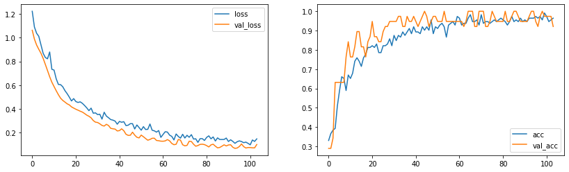

```python
df = df.sample(frac=1)
x = df.iloc[:,:-1]
y = pd.get_dummies(df['species'])

dnn = Sequential([Dense(64, 'relu', input_dim=x.shape[1]), Dropout(0.2), Dense(32, 'relu'), Dense(y.shape[1], 'softmax')])
dnn.compile('adam', 'categorical_crossentropy', 'acc')

earlyStopping = callbacks.EarlyStopping(patience=10, restore_best_weights=True)

history = dnn.fit(x, y, epochs=1000, verbose=0, validation_split=0.25, callbacks=earlyStopping)
print(f'Epoch {earlyStopping.stopped_epoch}: early stopping')
dnn_loss, dnn_acc = dnn.evaluate(x, y, verbose=0)
print(f'Loss: {dnn_loss:.3f}  Acc: {dnn_acc:.3f}')

plot_history()
```

**1.2.2 K折交叉验证K-fold cross-validation**：将数据分为K个子集，每次选取一个子集作验证集其余作训练集，遍历k次得到k个误差的平均值即交叉验证误差，用以最终评价模型 (回归用 [KFold]，分类用 [StratifiedKFold] 同时传入分类数据保证样本平衡)

自助法Bootstrap：每次有放回地随机采样选取训练集，适用于数据量很小的情况 (对应 [ShuffleSplit] 和 [StratifiedShuffleSplit])

```python
df = pd.read_csv('iris.csv')
x = df.iloc[:,:-1].values
y = pd.get_dummies(df['species']).values
cv_loss, cv_acc, k_count = [], [], 1

for train, test in StratifiedKFold(5, True).split(x, df['species']):
    x_train, x_test, y_train, y_test = x[train], x[test], y[train], y[test]
    dnn = Sequential([Dense(64, 'relu', input_dim=x.shape[1]), Dense(32, 'relu'), Dense(y.shape[1], 'softmax')])
    dnn.compile('adam', 'categorical_crossentropy', 'acc')
    dnn.fit(x_train, y_train, epochs=50, verbose=0)
    test_loss, test_acc = dnn.evaluate(x_test, y_test, verbose=0)
    print(f'Fold {k_count}:  Loss: {test_loss:.3f}  Acc: {test_acc:.3f}')
    cv_loss.append(test_loss)
    cv_acc.append(test_acc)
    k_count += 1

print(f'Cross Validation:  Loss: {np.mean(cv_loss):.3f}  Acc: {np.mean(cv_acc):.3f}')
```

```
Fold 1:  Loss: 0.149  Acc: 0.967
Fold 2:  Loss: 0.183  Acc: 0.967
Fold 3:  Loss: 0.241  Acc: 0.933
Fold 4:  Loss: 0.197  Acc: 0.967
Fold 5:  Loss: 0.184  Acc: 1.000
Cross Validation:  Loss: 0.191  Acc: 0.967
```

**1.2.3 摄动法Input perturbation**：一种评价特征重要性的方法，将某一列数据打乱即破坏后进行模型预测，由此得到的误差用来评估该列特征的重要性

```python
def perturbation_rank(model, x, y, features):
    errs = []
    for i in range(x.shape[1]):
        hold = x[:,i]
        np.random.shuffle(x[:,i])
        errs.append(model.evaluate(x, y, verbose=0))
        x[:,i] = hold
    importance = [err/np.max(errs) for err in errs]
    rank = pd.DataFrame({'feature':features, 'error':errs, 'importance':importance})
    rank = rank.sort_values('importance', ascending=False).reset_index(drop=True)
    return rank
```

```python
df = pd.read_csv('iris.csv')
x = df.iloc[:,:-1].values
y = pd.get_dummies(df['species']).values
x_train, x_test, y_train, y_test = train_test_split(x, y)

dnn = Sequential([Dense(64, 'relu', input_dim=x.shape[1]), Dense(32, 'relu'), Dense(y.shape[1], 'softmax')])
dnn.compile('adam', 'categorical_crossentropy')
dnn.fit(x_train, y_train, epochs=50, verbose=0)

features = df.iloc[:,:-1].columns
perturbation_rank(dnn, x_test, y_test, features)
```

|  | feature | error | importance |
| --- | --- | --- | --- |
| 0 | petal_w | 3.587844 | 1.000000 |
| 1 | petal_l | 2.353014 | 0.655830 |
| 2 | sepal_w | 0.167186 | 0.046598 |
| 3 | sepal_l | 0.163205 | 0.045488 |

**1.2.4 贝叶斯优化Bayesian optimization**：一种自动调参方法，通过高斯过程对目标函数建模得到后验分布再进行贝叶斯优化，包括探索exploration在未取样的区域获取采样点表示均值，和开发exploitation根据后验概率在最可能出现全局最优解的区域进行采样表示方差 (最大化目标函数故若目标函数为损失则取负值)

```python
df = pd.read_csv('iris.csv')
x = df.iloc[:,:-1]
y = pd.get_dummies(df['species'])
x_train, x_test, y_train, y_test = train_test_split(x, y)

def target(layer1, layer2):
    dnn = Sequential([Dense(layer1, 'relu', input_dim=x.shape[1]), Dense(layer2, 'relu'), Dense(y.shape[1], 'softmax')])
    dnn.compile('adam', 'categorical_crossentropy')
    dnn.fit(x_train, y_train, epochs=5, verbose=0)
    return -dnn.evaluate(x_test, y_test, verbose=0)

pbounds = {'layer1':(1,500), 'layer2':(1,500)}
BayesianOptimization(target, pbounds, verbose=1).maximize()
```

```
|   iter    |  target   |  layer1   |  layer2   |
-------------------------------------------------
|  2        | -0.4532   |  462.2    |  279.2    |
|  4        | -0.4401   |  222.9    |  449.6    |
|  6        | -0.4331   |  500.0    |  500.0    |
|  9        | -0.4221   |  327.2    |  350.8    |
|  10       | -0.3109   |  498.6    |  498.0    |
=================================================
```

### 1.3 模型评价指标

**1.3.1 二分类模型评价指标**

准确率召回率曲线PR(Precision-Recall)：用于评价二分类器，曲线越凸向右上则效果越好，F1值兼顾了准确率和召回率，取值 [0, 1]，值越大分类效果越好

接收者操作特征曲线ROC(Receiver Operating Characteristic)：不同分类阈值下的正例率TPR(True Positive Rate)和伪正例率FPR(False Positive Rate)，对应敏感性sensitivity和特异性1-specificity，用于评价二分类器，曲线越凸向左上则效果越好 (与PR曲线相比不随正负样本的分布变化而变化)

曲线下面积AUC(Area Under Curve)：一般指ROC曲线下的面积，取值 [0.5, 1]，AUC=0.5 代表随机猜测，AUC=1 代表完美分类，值越大分类效果越好

Tip：二分类模型得到的结果为概率，使用 [sklearn.metrics] 的 [f1_score] 时需要转化为分类结果即0或1的数组

```python
def plot_pr(y_true, y_pred):
    p, r, _ = precision_recall_curve(y_true, y_pred)
    calss_pred = []
    for a in y_pred:
        calss_pred.append(0 if a < 0.5 else 1)
    f1 = f1_score(y_true, calss_pred)
    plt.plot(r, p, label='PR curve (F1 score = %.3f)' % f1)
    plt.xlabel('Recall')
    plt.ylabel('Precision')
    plt.title('Precision-Recall (PR)')
    plt.legend()

def plot_roc(y_true, y_pred):
    fpr, tpr, _ = roc_curve(y_test, y_pred)
    roc_auc = auc(fpr, tpr)
    plt.plot(fpr, tpr, label='ROC curve (AUC = %0.3f)' % roc_auc)
    plt.plot([0, 1], [0, 1], 'k--')
    plt.xlim([-0.05, 1])
    plt.ylim([0, 1.05])
    plt.xlabel('False Positive Rate (FPR)')
    plt.ylabel('True Positive Rate (TPR)')
    plt.title('Receiver Operating Characteristic (ROC)')
    plt.legend()
```

```python
df = pd.read_csv('wcbreast_wdbc.csv', index_col=0)
df.head()
```

| id | diagnosis | mean_radius | mean_texture | mean_perimeter | mean_area | mean_smoothness | mean_compactness | mean_concavity | mean_concave_points | mean_symmetry | ... | worst_radius | worst_texture | worst_perimeter | worst_area | worst_smoothness | worst_compactness | worst_concavity | worst_concave_points | worst_symmetry | worst_fractal_dimension |
| --- | --- | --- | --- | --- | --- | --- | --- | --- | --- | --- | --- | --- | --- | --- | --- | --- | --- | --- | --- | --- | --- |
| 842302 | M | 17.99 | 10.38 | 122.80 | 1001.0 | 0.11840 | 0.27760 | 0.3001 | 0.14710 | 0.2419 | ... | 25.38 | 17.33 | 184.60 | 2019.0 | 0.1622 | 0.6656 | 0.7119 | 0.2654 | 0.4601 | 0.11890 |
| 842517 | M | 20.57 | 17.77 | 132.90 | 1326.0 | 0.08474 | 0.07864 | 0.0869 | 0.07017 | 0.1812 | ... | 24.99 | 23.41 | 158.80 | 1956.0 | 0.1238 | 0.1866 | 0.2416 | 0.1860 | 0.2750 | 0.08902 |
| 84300903 | M | 19.69 | 21.25 | 130.00 | 1203.0 | 0.10960 | 0.15990 | 0.1974 | 0.12790 | 0.2069 | ... | 23.57 | 25.53 | 152.50 | 1709.0 | 0.1444 | 0.4245 | 0.4504 | 0.2430 | 0.3613 | 0.08758 |
| 84348301 | M | 11.42 | 20.38 | 77.58 | 386.1 | 0.14250 | 0.28390 | 0.2414 | 0.10520 | 0.2597 | ... | 14.91 | 26.50 | 98.87 | 567.7 | 0.2098 | 0.8663 | 0.6869 | 0.2575 | 0.6638 | 0.17300 |
| 84358402 | M | 20.29 | 14.34 | 135.10 | 1297.0 | 0.10030 | 0.13280 | 0.1980 | 0.10430 | 0.1809 | ... | 22.54 | 16.67 | 152.20 | 1575.0 | 0.1374 | 0.2050 | 0.4000 | 0.1625 | 0.2364 | 0.07678 |

5 rows × 31 columns

```
Loss: 0.158  Acc: 0.951
```

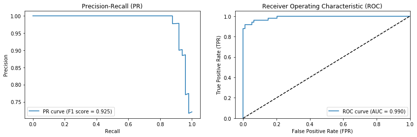

```python
x = df.iloc[:,1:]
x = StandardScaler().fit_transform(x)
y = df['diagnosis'].map({'M':1, 'B':0})
x_train, x_test, y_train, y_test = train_test_split(x, y)

dnn = Sequential([Dense(64, 'relu', input_dim=x.shape[1]), Dense(32, 'relu'), Dense(1, 'sigmoid')])
dnn.compile('adam', 'binary_crossentropy', 'acc')
dnn.fit(x_train, y_train, epochs=50, verbose=0)
test_loss, test_acc = dnn.evaluate(x_test, y_test, verbose=0)
print(f'Loss: {test_loss:.3f}  Acc: {test_acc:.3f}')

plt.figure(figsize=(14,4))
plt.subplot(121)
plot_pr(y_test, dnn.predict(x_test))
plt.subplot(122)
plot_roc(y_test, dnn.predict(x_test))
```

**1.3.2 多分类模型评价指标**

对数损失Log loss：即交叉熵crossentropy，用于量化概率分布间的差异并惩罚错误的分类来评价分类器，值越低分类效果越好 (作损失函数时二分类用binary_crossentropy，多分类独热编码用categorical_crossentropy，多分类多热编码用sparse_categorical_crossentropy)

混淆矩阵Confusion matrix：实际标签和预测结果构成的矩阵，用于评价分类器 (绘图前通常先作标准化，按每一行计算概率)

Tip：多分类y为独热编码时，模型预测及y本身都是概率矩阵，可用 [np.argmax] 提取最大概率得到分类数据，才能使用混淆矩阵

```python
def plot_cm(cm, labels):
    plt.imshow(cm, 'Blues', interpolation='nearest')
    plt.colorbar()
    ticks = np.arange(len(labels))
    plt.xticks(ticks, labels, rotation=45)
    plt.yticks(ticks, labels)
    plt.xlabel('Predicted labels')
    plt.ylabel('True labels')
    plt.title('Confusion Matrix')
```

```python
df = pd.read_csv('jh-simple-dataset.csv', index_col=0)
df.head()
```

| id | job | area | income | aspect | subscriptions | dist_healthy | save_rate | dist_unhealthy | age | pop_dense | retail_dense | crime | product |
| --- | --- | --- | --- | --- | --- | --- | --- | --- | --- | --- | --- | --- | --- |
| 1 | vv | c | 50876.0 | 13.100000 | 1 | 9.017895 | 35 | 11.738935 | 49 | 0.885827 | 0.492126 | 0.071100 | b |
| 2 | kd | c | 60369.0 | 18.625000 | 2 | 7.766643 | 59 | 6.805396 | 51 | 0.874016 | 0.342520 | 0.400809 | c |
| 3 | pe | c | 55126.0 | 34.766667 | 1 | 3.632069 | 6 | 13.671772 | 44 | 0.944882 | 0.724409 | 0.207723 | b |
| 4 | 11 | c | 51690.0 | 15.808333 | 1 | 5.372942 | 16 | 4.333286 | 50 | 0.889764 | 0.444882 | 0.361216 | b |
| 5 | kl | d | 28347.0 | 40.941667 | 3 | 3.822477 | 20 | 5.967121 | 38 | 0.744094 | 0.661417 | 0.068033 | a |

```
Loss: 0.916  Acc: 0.700
```

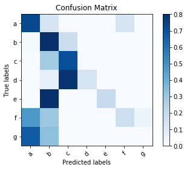

```python
df = df.fillna(df.median())
x = pd.concat([pd.get_dummies(df[['job', 'area']]), df.iloc[:,2:-1]], 1)
x = StandardScaler().fit_transform(x)
y = pd.get_dummies(df['product'])
x_train, x_test, y_train, y_test = train_test_split(x, y)

dnn = Sequential([Dense(64, 'relu', input_dim=x.shape[1]), Dense(32, 'relu'), Dense(y.shape[1], 'softmax')])
dnn.compile('adam', 'categorical_crossentropy', 'acc')
dnn.fit(x_train, y_train, epochs=50, verbose=0)
test_loss, test_acc = dnn.evaluate(x_test, y_test, verbose=0)
print(f'Loss: {test_loss:.3f}  Acc: {test_acc:.3f}')

y_true = np.argmax(y_test.values, 1)
y_pred = np.argmax(dnn.predict(x_test), 1)
cm = confusion_matrix(y_true, y_pred)
cm_normalized = cm / cm.sum(1)[:,np.newaxis]
plot_cm(cm_normalized, y.columns)
```

**1.3.3 回归模型评价指标**

均方误差MSE(Mean Squared Error)：预测值的平均平方损失，用于评价回归器，其算数平方根就是均方根误差RMSE(Root Mean Squared Error)

平均绝对误差MAE(Mean Absolute Error)：绝对误差的平均值，与RMSE相比不反应误差间的波动，MAE ≤ RMSE

平均绝对百分比误差MAPE(Mean Absolute Percentage Error)：绝对误差占真实值的平均百分比，真实值有零值时则不适用

残差图Residual plot：预测值与实际值的误差序列图，用于评价回归器，散点越符合0均值的白噪声分布则回归效果越好

Tip：作回归效果图时可用 [np.argsort] 将数据由小到大排序，更直观地观察预测效果

```python
def plot_reg(y_true, y_pred):
    x = np.linspace(min(y_true), max(y_true), len(y_true))
    index = np.argsort(y_true)
    plt.plot(x, y_true[index], label='True values')
    plt.plot(x, y_pred[index], label='Predicted values')
    plt.title('Regression Plot')
    plt.legend()
```

```python
df = pd.read_csv('auto-mpg.csv')
df.head()
```

|  | mpg | cylinders | displacement | horsepower | weight | acceleration | year | origin | name |
| --- | --- | --- | --- | --- | --- | --- | --- | --- | --- |
| 0 | 18.0 | 8 | 307.0 | 130 | 3504 | 12.0 | 70 | 1 | chevrolet chevelle malibu |
| 1 | 15.0 | 8 | 350.0 | 165 | 3693 | 11.5 | 70 | 1 | buick skylark 320 |
| 2 | 18.0 | 8 | 318.0 | 150 | 3436 | 11.0 | 70 | 1 | plymouth satellite |
| 3 | 16.0 | 8 | 304.0 | 150 | 3433 | 12.0 | 70 | 1 | amc rebel sst |
| 4 | 17.0 | 8 | 302.0 | 140 | 3449 | 10.5 | 70 | 1 | ford torino |

```
Mse: 7.957 (loss)  Rmse: 2.821  Mae: 2.077  Mape: 8.79%
```

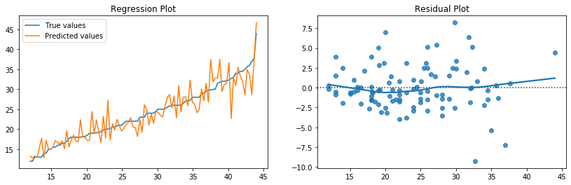

```python
df['horsepower'] = pd.to_numeric(df['horsepower'], 'coerce')
df = df.fillna(df.median())
x = df.iloc[:,1:-1]
x = StandardScaler().fit_transform(x)
y = df['mpg']
x_train, x_test, y_train, y_test = train_test_split(x, y)

dnn = Sequential([Dense(64, 'relu', input_dim=x.shape[1]), Dense(32, 'relu'), Dense(1)])
dnn.compile('adam', 'mse', ['RootMeanSquaredError','mae','mape'])
dnn.fit(x_train, y_train, epochs=300, verbose=0)
test_loss, test_rmse, test_mae, test_mape = dnn.evaluate(x_test, y_test, verbose=0)
print(f'Mse: {test_loss:.3f} (loss)  Rmse: {test_rmse:.3f}  Mae: {test_mae:.3f}  Mape: {test_mape:.2f}%')

plt.figure(figsize=(14,4))
plt.subplot(121)
plot_reg(y_test.values, dnn.predict(x_test))
plt.subplot(122)
plt.title('Residual Plot')
sns.residplot(y_test.values, dnn.predict(x_test), lowess=True)
plt.show()
```

### 1.4 时间序列分析Time Series Analysis

循环神经网络RNN(Recurrent Neural Network)：迭代时保留前次输出，用于处理序列数据，原始结构随着递归面临权重指数爆炸和梯度消失问题

长短期记忆LSTM(Long Short-Term Memory)：一种RNN优化结构，使用遗忘门输入门输出门来调节信息流，解决了长序列数据的训练问题

双向长短期记忆BLSTM(Bidirectional Long Short-Term Memory)：结合前后向序列分析，在文本音频等需要上下文的问题上往往比LSTM效果更好

门控循环单元GRU(Gated Recurrent Unit)：一种RNN优化结构，是LSTM的变种，基于更新门和重置门的门控系统，比LSTM的模型更简单

时间卷积网络TCN(Temporal Convolutional Network)：应用一维卷积的CNN网络，适用于处理时序数据，同时加入残差卷积以提高准确率

```python
df = pd.read_csv('SN_d_tot_V2.0.csv', ';', header=None).iloc[-2500:,:-1].reset_index(drop=True)
df.head()
```

|  | 0 | 1 | 2 | 3 | 4 | 5 | 6 |
| --- | --- | --- | --- | --- | --- | --- | --- |
| 0 | 2013 | 7 | 28 | 2013.571 | 73 | 4.2 | 21 |
| 1 | 2013 | 7 | 29 | 2013.574 | 103 | 5.2 | 19 |
| 2 | 2013 | 7 | 30 | 2013.577 | 89 | 4.8 | 17 |
| 3 | 2013 | 7 | 31 | 2013.579 | 103 | 6.4 | 21 |
| 4 | 2013 | 8 | 1 | 2013.582 | 96 | 4.8 | 21 |

```python
def to_sequence(size, arr):
    x, y = [], []
    for i in range(len(arr)-size):
        x.append([[n] for n in arr[i:i+size]])
        y.append(arr[i+size])
    return np.array(x), np.array(y)

sn_train = df.iloc[:-500,4].astype('f').tolist()
sn_test = df.iloc[-500:,4].astype('f').tolist()
x_train, y_train = to_sequence(10, sn_train)
x_test, y_test = to_sequence(10, sn_test)

rnn = Sequential([LSTM(64, input_shape=(None,1)), Dense(32, 'relu'), Dense(1)])
rnn.compile('adam', 'mse', ['RootMeanSquaredError','mae'])
rnn.fit(x_train, y_train, epochs=5, verbose=0)
test_loss, test_rmse, test_mae = rnn.evaluate(x_test, y_test, verbose=0)
print(f'RNN(LSTM):  Mse: {test_loss:.3f} (loss)  Rmse: {test_rmse:.3f}  Mae: {test_mae:.3f}')

cnn = Sequential([Conv1D(64, 3, activation='relu', input_shape=(10,1)),
                  MaxPool1D(), Flatten(), Dense(64, 'relu'), Dense(1)])
cnn.compile('adam', 'mse', ['RootMeanSquaredError','mae'])
cnn.fit(x_train, y_train, epochs=5, verbose=0)
test_loss, test_rmse, test_mae = cnn.evaluate(x_test, y_test, verbose=0)
print(f'CNN(TCN):  Mse: {test_loss:.3f} (loss)  Rmse: {test_rmse:.3f}  Mae: {test_mae:.3f}')
```

```
RNN(LSTM):  Mse: 15.811 (loss)  Rmse: 3.976  Mae: 2.883
CNN(TCN):  Mse: 17.014 (loss)  Rmse: 4.125  Mae: 2.275
```

## 2. 计算机视觉CV(Computer Vision)

数据预处理：图像数据是三维数据，输入卷积层前需要 [reshape] 添加图像通道channel为第四维，并将数据作 [x/255] 或 [x/127.5-1] 归一化

**2.1 卷积神经网络CNN(Convolutional Neural Network)**：通常包含卷积层池化层和密集层，卷积层convolutional layer通过滤波器filter扫描图像提取特征，再经过池化层pooling layer进行压缩保留突出特征，然后通过扁平层flatten将数据一维化后输入密集层进行模型训练

```
Loss: 0.045  Acc: 0.987
Some of the test labels:
 [7 2 1 0 4 1 4 9 5 9 0 6 9 0 1 5 9 7 3 4 9 6 6 5 4]
```

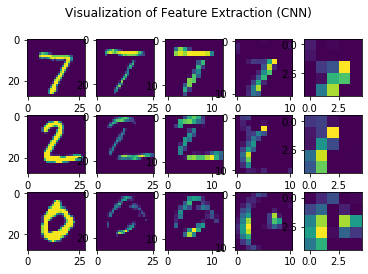

```python
(img_train, y_train),(img_test, y_test) = datasets.mnist.load_data()
x_train = img_train.reshape(60000,28,28,1) / 255
x_test = img_test.reshape(10000,28,28,1) / 255

cnn = Sequential([Conv2D(64, 3, activation='relu', input_shape=(28,28,1)), MaxPool2D(),
                  Conv2D(64, 3, activation='relu'), MaxPool2D(),
                  Flatten(), Dense(128, 'relu'), Dense(10, 'softmax')])
cnn.compile('adam', 'sparse_categorical_crossentropy', 'acc')
cnn.fit(x_train, y_train, epochs=1, verbose=0)
test_loss, test_acc = cnn.evaluate(x_test, y_test, verbose=0)
print(f'Loss: {test_loss:.3f}  Acc: {test_acc:.3f}')

def demo(idx1, idx2, idx3, idx_conv):
    print('Some of the test labels:\n', y_test[:25])
    cnn_outputs = [layer.output for layer in cnn.layers]
    cnn_demo = Model(cnn.input, cnn_outputs)
    fig, axes = plt.subplots(3, 5)
    fig.suptitle('Visualization of Feature Extraction (CNN)')
    for i in range(1,5):
        demo1 = cnn_demo.predict(img_test[idx1].reshape(1,28,28,1))[i-1]
        axes[0,0].imshow(img_test[idx1])
        axes[0,i].imshow(demo1[0,:,:,idx_conv])
        demo2 = cnn_demo.predict(img_test[idx2].reshape(1,28,28,1))[i-1]
        axes[1,0].imshow(img_test[idx2])
        axes[1,i].imshow(demo2[0,:,:,idx_conv])
        demo3 = cnn_demo.predict(img_test[idx3].reshape(1,28,28,1))[i-1]
        axes[2,0].imshow(img_test[idx3])
        axes[2,i].imshow(demo3[0,:,:,idx_conv])

demo(0, 1, 3, 5)
```

**2.2 图像数据增强Image data augmentation**：通过剪裁旋转变换等方式从有限的数据中产生更多数据，适用于数据量少的情况

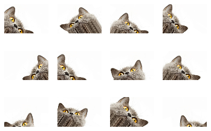

```python
datagen = ImageDataGenerator(rotation_range=40, width_shift_range=0.2, height_shift_range=0.2,
                             shear_range=0.2, zoom_range=0.2, horizontal_flip=True, rescale=1./255)
img, i = np.expand_dims(np.array(Image.open('aug_test.jpg')),0), 1

for batch in datagen.flow(img):
    for item in batch:
        plt.subplot(3,4,i)
        plt.imshow(item)
        plt.axis('off')
    if i < 12: i += 1
    else: break
```

**2.3 残差网络ResNet(Residual Network)**：一种CNN网络结构，利用跨层残差连接解决了深层网络的退化问题

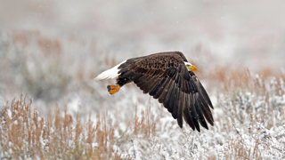

```
Pred 1: bald_eagle, 0.9997166991233826
Pred 2: kite, 0.0002325290988665074
Pred 3: vulture, 5.007846630178392e-05
Pred 4: albatross, 3.0217236712815065e-07
Pred 5: black_stork, 2.925165460965218e-07
```

```python
img_raw = np.array(Image.open('resnet_test.jpg').resize((224,224)))
img = preprocess_input(np.expand_dims(img_raw, 0))

resnet50 = ResNet50V2()
preds = resnet50.predict(img)
items = decode_predictions(preds)[0]

display(Image.open('resnet_test.jpg').resize((320,180)))
for i in range(5): print(f'Pred {i+1}: {items[i][1]}, {items[i][2]}')
```

**2.4 YOLO(You Only Look Once)**：一种基于CNN网络的目标检测object detection算法

[figure not shown]

```python
root_weight = 'C:\\Tech_basic\\Jupyter Workplace\\@transfer\\yolov3_tf2\\yolov3.tf'
root_names = 'C:\\Tech_basic\\Jupyter Workplace\\@transfer\\yolov3_tf2\\coco.names'
class_names = [s.strip() for s in open(root_names).readlines()]

img_raw = np.array(Image.open('yolo_test.jpg').resize((900,600)))
img = transform_images(np.expand_dims(img_raw, 0), 416)

FLAGS([sys.argv[0]])
yolo = YoloV3()
yolo.load_weights(root_weight).expect_partial()

result = draw_outputs(img_raw, yolo(img), class_names)
display(Image.fromarray(result).resize((600,400)))
```

生成对抗网络GAN(Generative Adversarial Network)：基于生成器generator和判别器discriminator相互博弈式的训练过程，最早应用于无监督学习

**2.5 迁移学习Transfer learning**：使用预训练的模型作预测、特征提取和微调fine-tuning，常见于CV和NLP领域 (预测见残差网络直接导入模型，特征提取只需将top层选否，微调就是在特征提取的基础上添加并仅训练密集层)

```
Found 9 images belonging to 3 classes.
Train loss: 0.000  Train acc: 1.000
```

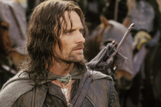

```
Names: ['Aragorn', 'Frodo', 'Gandalf']
Probs: [0.999613, 6.31e-05, 0.0003239]
Result: Aragorn
```

```python
train_datagen = ImageDataGenerator(preprocessing_function=preprocess_input)
train_generator = train_datagen.flow_from_directory('transfer_train',(224,224))
img_raw = np.array(Image.open('transfer_test.jpg').resize((224,224)))
img = preprocess_input(np.expand_dims(img_raw, 0))

base = ResNet50V2(False, pooling='avg')
x = Dense(1024, 'relu')(base.output)
preds = Dense(3, 'softmax')(x)
model = Model(base.input, preds)
for layer in base.layers: layer.trainable=False

model.compile('adam', 'categorical_crossentropy', 'acc')
model.fit(train_generator, epochs=5, verbose=0)
train_loss, train_acc = model.evaluate(train_generator, verbose=0)
print(f'Train loss: {train_loss:.3f}  Train acc: {train_acc:.3f}')

names = list(train_generator.class_indices)
probs = model.predict(img)[0]
display(Image.open('transfer_test.jpg').resize((270,180)))
print(f'Names: {names}\nProbs: {[np.round(p,7) for p in probs]}')
print(f'Result: {names[np.argmax(probs)]}')
```

## 3. 自然语言处理NLP(Natural Language Processing)

数据预处理：使用 [Tokenizer] 对文本建立词典，用 [texts_to_sequences] 将句子转化为序列，再用 [pad_sequences] 将序列填充为相同长度

**3.1 嵌入层Embedding**：将正整数索引转换为固定大小的稠密向量，输出二维数据，可以通过扁平层一维化后接入密集层作模型训练

```
Loss: 0.010  Acc: 1.000
Visualization: https://projector.tensorflow.org/
```

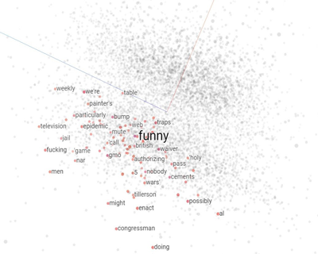

```python
data = json.load(open('sarcasm.json'))
sentences, labels = [], []
for item in data[:3000]:
    sentences.append(item['headline'])
    labels.append(item['is_sarcastic'])

tokenizer = Tokenizer()
tokenizer.fit_on_texts(sentences)
word_index = tokenizer.word_index
sequences = tokenizer.texts_to_sequences(sentences)
padded = pad_sequences(sequences)

model = Sequential([Embedding(len(word_index)+1, 16, input_length=padded.shape[1]),
                    Flatten(), Dense(16, 'relu'), Dense(1, 'sigmoid')])
model.compile('adam', 'binary_crossentropy', 'acc')
model.fit(padded, np.array(labels), epochs=5, verbose=0)
model_loss, model_acc = model.evaluate(padded, np.array(labels), verbose=0)
print(f'Loss: {model_loss:.3f}  Acc: {model_acc:.3f}')

weights = model.layers[0].get_weights()[0]
reverse_word_index = dict([(v,k) for (k,v) in word_index.items()])
out_v = open('vecs.tsv', 'w', encoding='utf-8')
out_m = open('meta.tsv', 'w', encoding='utf-8')
for i in range(len(word_index)):
    out_v.write('\t'.join([str(v) for v in weights[i]]) + '\n')
    out_m.write(reverse_word_index[i+1] + '\n')
out_v.close()
out_m.close()

print('Visualization: https://projector.tensorflow.org/')
display(Image.open('projector.jpg').resize((400,320)))
```

**3.2 词嵌入迁移学习**：使用 [*TF Hub*] 的预训练模型完成词嵌入，可以直接输入文本数据并接密集层作文本分类

```python
data_train, data_test = tfds.load('imdb_reviews', split=['train','test'], batch_size=-1, as_supervised=True)
x_train, y_train = tfds.as_numpy(data_train)
x_test, y_test = tfds.as_numpy(data_test)
x_train, y_train, x_test, y_test = x_train[:1000], y_train[:1000], x_test[:200], y_test[:200]

root = 'C:\\Tech_basic\\Jupyter Workplace\\@transfer\\tf_hub\\text\\tf2-preview_gnews-swivel-20dim_1'
hub_layer = hub.KerasLayer(root, output_shape=[20], input_shape=[], dtype=tf.string, trainable=True)

model = Sequential([hub_layer, Dense(16, 'relu'), Dense(1, 'sigmoid')])
model.compile('adam', 'binary_crossentropy', 'acc')
model.fit(x_train, y_train, epochs=20, verbose=0)
test_loss, test_acc = model.evaluate(x_test, y_test, verbose=0)
print(f'Loss: {test_loss:.3f}  Acc: {test_acc:.3f}')
```

```
Loss: 0.444  Acc: 0.780
```

**3.3 Word2Vec**：一种词嵌入word embedding的模型，语意相近的词在向量空间内距离也相近

```python
root = 'C:\\Tech_basic\\Jupyter Workplace\\@transfer\\word2vec\\GoogleNews-vectors-negative300.bin.gz'
model = KeyedVectors.load_word2vec_format(root, binary=True)

print('Similarity between king and man:', model.similarity('king','man'))
print('Similarity between king and queen:', model.similarity('king','queen'))
print('Most similar word to king:\n', model.most_similar('king',topn=3))
print('Most similar word to king + woman - man:\n', model.most_similar(['king','woman'],['man'],topn=3))
```

```
Similarity between king and man: 0.22942671
Similarity between king and queen: 0.6510957
Most similar word to king:
 [('kings', 0.7138045430183411), ('queen', 0.6510956883430481), ('monarch', 0.6413194537162781)]
Most similar word to king + woman - man:
 [('queen', 0.7118192911148071), ('monarch', 0.6189674139022827), ('princess', 0.5902431607246399)]
```

**3.4 文本生成**：可以看作对文本数据的序列分析，预测值需独热编码，对连续数据的序列分析见 [*1.4 时间序列分析Time Series Analysis*]

Tip：同一模型中使用多个LSTM时，需将前几个的 [return_sequences] 设置为 [True]

```python
corpus = open('sonnets.txt').read().split('\n')[:50]
tokenizer = Tokenizer()
tokenizer.fit_on_texts(corpus)

input_sequences = []
for line in corpus:
    sequence = tokenizer.texts_to_sequences([line])[0]
    for i in range(len(sequence)):
        input_sequences.append(sequence[:i+2])

maxlen = max([len(x) for x in input_sequences])
input_padded = pad_sequences(input_sequences, maxlen)
x, y = input_padded[:,:-1], input_padded[:,-1]
y = utils.to_categorical(y)

rnn = Sequential([Embedding(y.shape[1], 64, input_length=maxlen-1),
                  Bidirectional(LSTM(128, return_sequences=True)),
                  LSTM(64), Dense(64, 'relu'), Dense(y.shape[1], 'softmax')])
rnn.compile('adam', 'categorical_crossentropy', 'acc')
rnn.fit(x, y, epochs=100, verbose=0)
rnn_loss, rnn_acc = rnn.evaluate(x, y, verbose=0)
print(f'Loss: {rnn_loss:.3f}  Acc: {rnn_acc:.3f}')

reverse_word_index = dict([(v,k) for (k,v) in tokenizer.word_index.items()])
seed_text = 'Look'
for _ in range(10):
    sequence = tokenizer.texts_to_sequences([seed_text])[0]
    padded = pad_sequences([sequence], maxlen-1)
    pred = np.argmax(rnn.predict(padded))
    word = reverse_word_index[pred]
    seed_text += ' ' + word
print(f'Generated Sonnet: {seed_text}')
```

```
Loss: 0.719  Acc: 0.851
Generated Sonnet: Look dost thou use tillage thy face thou viewest brow live
```